# Vancouver Tree Height Geography Analysis

Author

DSCI 522, Group 33- Derek Rogers, Gunisha Kaur, Jessie Zhang, Zheng He

Published

December 16, 2024

## Summary

Our group explored the question, “Do tree heights vary significantly from neighborhood to neighborhood in Vancouver?” The analysis focused on understanding the relationship between tree height distribution and neighborhoods. Specifically, we examined tree height ranges and their counts across different neighborhoods to assess whether location influences tree height.

The findings revealed a statistically significant effect of neighborhood on tree height. This indicates that tree height is not uniform across Vancouver but varies systematically depending on the neighborhood. Certain neighborhoods were characterized by a higher proportion of taller trees, while others predominantly featured shorter trees. These patterns suggest that factors such as environmental conditions, soil quality, local climate, or urban planning decisions might play a critical role in influencing tree height distribution.

This analysis provides valuable insights that could inform urban forestry management and planning efforts, helping to ensure an equitable distribution of tree-related benefits such as shade, air quality improvement, and aesthetic value across the city.

## Introduction

Urban trees are essential to creating livable cities, offering ecological, aesthetic, and health benefits. They improve air quality, provide shade, support biodiversity, and enhance the overall urban environment. The City of Vancouver (2018) considers street trees to be a vital part of its commitment to sustainability. However, the characteristics of these trees, such as their heights, can vary significantly across neighborhoods due to factors like local urban planning, soil quality, and maintenance practices. Understanding these patterns is key to equitable urban forestry management and informed decision-making.

This project explores the relationship between **tree height distribution** and **neighborhoods** in Vancouver using data from the City of Vancouver Open Data Portal (2022).

To address this, we analyze the dataset through a combination of:

1. **Exploratory Data Analysis (EDA):** We use contingency tables and visualizations (heatmaps) to identify patterns in tree height distributions across neighborhoods.
2. **Statistical Testing:** A Chi-squared test of independence is performed to determine if the observed variations in tree height distributions are statistically significant.

By uncovering these patterns, this analysis contributes to urban forestry strategies that aim to distribute greenery benefits equitably across neighborhoods in Vancouver. The findings could help guide future decisions in tree planting, maintenance, and sustainable urban planning.

## Methods and Results

### Cleaning the Data

In our analysis, we are primarily interested in the `NEIGHBOURHOOD_NAME`, `HEIGHT_RANGE`, and `HEIGHT_RANGE_ID` columns in the street trees dataset, so it is crucial to ensure that there are no missing values in these columns to maintain the accuracy and reliability of our statistical results. Upon checking, we confirmed that none of these three columns contain any missing data.

Additionally, we examined the entire dataset for duplicate records using the unique identifier `TREE_ID` and confirmed that there are no duplicate rows. This step ensures that no records are inadvertently counted multiple times.

### Exploratory Data Analysis (EDA)

For EDA, the columns of interest are:

1. `NEIGHBOURHOOD_NAME` (the explanatory/treatment variable) is a string representing the neighbourhood the tree is in.
2. Tree height data (the outcome/response variable) is represented in two columns, in different formats:
   1. `HEIGHT_RANGE` is a string representing tree heights (categorical levels) in buckets of 10ft, e.g. `0' - 10'`, `10' - 20'`, etc.
   2. `HEIGHT_RANGE_ID` is a numeric column (integers) with levels corresponding to the above strings.

First, we should examine the levels of the two available versions of the response categorical variable (height), because we may be able to choose one that will simplify our subsequent analysis.

Based on the data, it looks like there should be a one-to-one correspondence between levels of `HEIGHT_RANGE` and `HEIGHT_RANGE_ID`, but we should confirm this. To do this, we can look at all unique combinations of the two variables. If they properly correspond (there are no issues with the data), we should see only one row for each. We will print the results using the `kable()` function from the `knitr` package by Xie (2014).

| HEIGHT_RANGE | HEIGHT_RANGE_ID |
| --- | --- |
| 0’ - 10’ | 0 |
| 10’ - 20’ | 1 |
| 20’ - 30’ | 2 |
| 30’ - 40’ | 3 |
| 40’ - 50’ | 4 |
| 50’ - 60’ | 5 |
| 60’ - 70’ | 6 |
| 70’ - 80’ | 7 |
| 80’ - 90’ | 8 |
| 90’ - 100’ | 9 |
| > 100’ | 10 |

Table 1: Mapping between tree height category names and their IDs.

From Table 1, we can see that there is a proper correspondence between the levels of these two variables. Since the levels of `HEIGHT_RANGE_ID` are simpler and shorter, we will use this variable. This should make our plots easier to display.

Using the `tabyl()` function from the `janitor` package by Firke (2023), we built a contingency table from the `NEIGHBOURHOOD_NAME` and `HEIGHT_RANGE_ID` columns (Table 2).

| NEIGHBOURHOOD_NAME | 0 | 1 | 2 | 3 | 4 | 5 | 6 | 7 | 8 | 9 | 10 |
| --- | --- | --- | --- | --- | --- | --- | --- | --- | --- | --- | --- |
| ARBUTUS RIDGE | 9 | 1552 | 1370 | 1301 | 712 | 321 | 273 | 181 | 99 | 34 | 25 |
| DOWNTOWN | 212 | 1887 | 2447 | 1769 | 1858 | 760 | 516 | 408 | 314 | 272 | 563 |
| DUNBAR-SOUTHLANDS | 11 | 2335 | 2446 | 1443 | 1130 | 979 | 773 | 481 | 207 | 53 | 41 |
| FAIRVIEW | 13 | 998 | 1036 | 830 | 1042 | 421 | 236 | 81 | 33 | 15 | 7 |
| GRANDVIEW-WOODLAND | 12 | 1944 | 1700 | 1273 | 1119 | 421 | 226 | 84 | 45 | 25 | 0 |
| HASTINGS-SUNRISE | 36 | 3884 | 3133 | 2247 | 1994 | 966 | 497 | 282 | 109 | 42 | 61 |
| KENSINGTON-CEDAR COTTAGE | 30 | 3456 | 3198 | 2062 | 2260 | 869 | 465 | 188 | 142 | 56 | 90 |
| KERRISDALE | 37 | 2058 | 2282 | 1240 | 1125 | 1018 | 619 | 421 | 260 | 151 | 130 |
| KILLARNEY | 42 | 2119 | 2380 | 1458 | 1468 | 498 | 300 | 180 | 79 | 88 | 86 |
| KITSILANO | 94 | 1599 | 2090 | 1679 | 1882 | 1192 | 857 | 467 | 163 | 70 | 28 |
| MARPOLE | 13 | 2260 | 2298 | 1265 | 1155 | 437 | 201 | 115 | 90 | 72 | 53 |
| MOUNT PLEASANT | 3 | 1771 | 1733 | 1589 | 1281 | 343 | 157 | 69 | 38 | 15 | 0 |
| OAKRIDGE | 67 | 1915 | 2301 | 1138 | 760 | 556 | 293 | 187 | 81 | 66 | 62 |
| RENFREW-COLLINGWOOD | 38 | 5056 | 3310 | 2085 | 1753 | 554 | 194 | 125 | 51 | 15 | 32 |
| RILEY PARK | 42 | 2238 | 2560 | 1576 | 1594 | 607 | 424 | 256 | 186 | 112 | 242 |
| SHAUGHNESSY | 48 | 1696 | 2061 | 1169 | 1233 | 1089 | 869 | 564 | 254 | 151 | 201 |
| SOUTH CAMBIE | 22 | 1020 | 1234 | 467 | 499 | 242 | 192 | 98 | 41 | 19 | 31 |
| STRATHCONA | 11 | 1109 | 812 | 515 | 547 | 232 | 106 | 55 | 32 | 27 | 38 |
| SUNSET | 59 | 3182 | 2549 | 1470 | 1396 | 405 | 164 | 102 | 66 | 133 | 164 |
| VICTORIA-FRASERVIEW | 34 | 3287 | 2314 | 1599 | 1147 | 359 | 115 | 73 | 10 | 7 | 28 |
| WEST END | 7 | 801 | 993 | 924 | 708 | 404 | 187 | 90 | 44 | 16 | 11 |
| WEST POINT GREY | 53 | 1233 | 1321 | 1005 | 955 | 751 | 574 | 342 | 136 | 91 | 128 |

Table 2: Contingency table showing counts of trees in various levels of the tree height variable per levels of the neighbourhood variable.

In order to better understand patterns in this data, we can use the `ggplot2` package by Wickham (2016) to visualize the above contingency table as a two-dimensional histogram, also known as heat map (Figure 1).

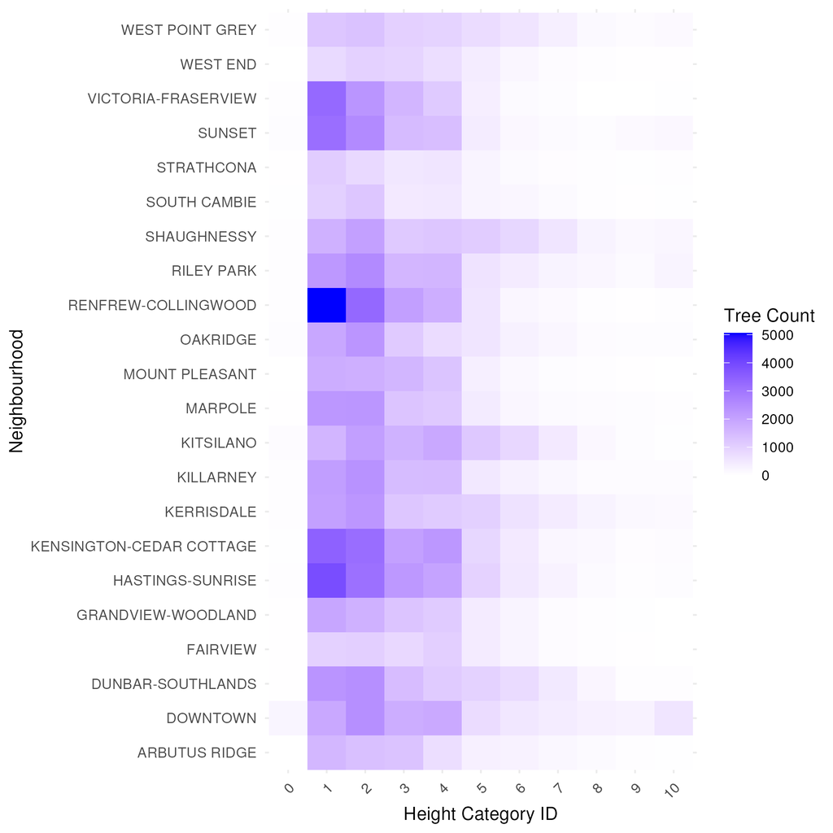

Figure 1: Heatmap of Tree Height Distribution by Neighbourhood

From Figure 1, it looks like there may be some differences in tree heights across neighbourhoods. In particular:

- `RENFREW-COLLINGWOOD` has, by a large margin, the most trees in the 10’ - 20’ height category (ID 1)
- `VICTORIA-FRASERVIEW`, `SUNSET`, `RENFREW-COLLINGWOOD`, `KENSINGTON-CEDAR COTTAGE`, and `HASTINGS-SUNRISE` seem to have more trees in the lower height categories (1-4) than other neighbourhoods.
- `SHAUGHNESSY` and `DOWNTOWN` seem to have the tallest trees.

### Statistical Test

Although there are some visually identifiable patterns, we can only determine whether there are statistically significant differences in tree heights per neighbourhood using an appropriate test.

#### Choosing a Test and Significance Level

Because we are dealing with two categorical variables, each with multiple levels, a Chi-squared test of Independence/Homogeneity is appropriate (Soetewey (2020)).

Our hypotheses are:  
**Null Hypothesis ($H_0$)**: The tree height is independent from different neighborhoods (no association).  
**Alternative Hypothesis ($H_A$)**: There is a statistically significant association between neighborhood and tree height.

The Chi-squared test makes the following assumptions:

1. The observations are independent.
2. The expected counts are large enough (greater than 5 is typical).

First, the height measurement of a particular tree does not depend on that of another, so we can assume independence. Second, almost every intersection of the contingency table has counts much larger than 5, with many in the hundreds or thousands.

Because neither of the test’s two key assumptions appear to be violated, it is safe to proceed with a Chi-squared test of independence.

Finally, we will choose the standard significance level of $\alpha = 0.05$ as our threshold for determining statistical significance.

#### Results of a Chi-squared Test of Independence

Our Chi-squared test of independence yielded a statistically significant result, with a test statistic of $1.5520197\times 10^{4}$ and a p-value of $0$, which is less than our predefined significance level of 0.05.

## Discussion

After conducting the analysis, we conclude that tree heights vary significantly across neighborhoods. The Chi-squared test of independence result shows the p-value approximately equal to zero and thus less than our predefined significance level of 0.05. Therefore, we can reject null hypothesis that the two categorical variables are independent (there is no association). This means that there is a statistically significant association between neighborhood and tree height.

Across neighborhoods, the most common tree height range appears to be between 1 and 3 units (height range ID referring to the specific tree height), indicating that the urban tree population is predominantly composed of younger or medium-sized trees. Taller trees (height range 6-10 units) are scarce or entirely absent in most neighborhoods, which may reflect the challenges posed by urban constraints such as limited space, infrastructure interference, or deliberate pruning practices to control growth.

Ecologically, neighborhoods with a higher density of trees, such as `RENFREW-COLLINGWOOD`, enjoy significant environmental benefits, including improved air quality, better urban cooling effects, and enhanced biodiversity. However, the dominance of trees in the 1-3 height range also suggests that many of these trees are young and might require additional care to ensure healthy growth into taller, mature trees.

Note that we do not have the evidence to state these insights and patterns are statstically significant, as the Chi-squared test does not specify which levels are significantly different.

## References

City of Vancouver. 2018. “Vancouver Urban Forestry Strategy.” https://vancouver.ca/files/cov/urban-forest-strategy.pdf.

City of Vancouver Open Data Portal. 2022. “Street Trees Dataset.” https://opendata.vancouver.ca/explore/dataset/street-trees/information/.

Firke, Sam. 2023. *Janitor: Simple Tools for Examining and Cleaning Dirty Data*. https://CRAN.R-project.org/package=janitor.

Soetewey, Antoine. 2020. “Chi-Square Test of Independence in r - Stats and r.” https://statsandr.com/blog/chi-square-test-of-independence-in-r/.

Wickham, Hadley. 2016. *Ggplot2: Elegant Graphics for Data Analysis*. Springer-Verlag New York. https://ggplot2.tidyverse.org.

Wickham, Hadley, and Garrett Grolemund. 2016. *R for Data Science: Import, Tidy, Transform, Visualize, and Model Data*. O’Reilly Media.

Xie, Yihui. 2014. “Knitr: A Comprehensive Tool for Reproducible Research in R.” In *Implementing Reproducible Computational Research*, edited by Victoria Stodden, Friedrich Leisch, and Roger D. Peng. Chapman; Hall/CRC.